# R Notebook

# Research Question

Kira Plastinina is a Russian brand that is sold through a defunct chain of retail stores in Russia, Ukraine, Kazakhstan, Belarus, China, Philippines, and Armenia. The brand’s Sales and Marketing team would like to understand their customer’s behavior from data that they have collected over the past year. More specifically, they would like to learn the characteristics of customer groups.

# Problem Definition

1. Perform clustering stating insights drawn from your analysis and visualizations.
2. Upon implementation, provide comparisons between the approaches learned this week i.e. K-Means clustering vs Hierarchical clustering highlighting the strengths and limitations of each approach in the context of your analysis.

### Data description

- The dataset consists of 10 numerical and 8 categorical attributes. The ‘Revenue’ attribute can be used as the class label.
- “Administrative”, “Administrative Duration”, “Informational”, “Informational Duration”, “Product Related” and “Product Related Duration” represents the number of different types of pages visited by the visitor in that session and total time spent in each of these page categories. The values of these features are derived from the URL information of the pages visited by the user and updated in real-time when a user takes an action, e.g. moving from one page to another.
- The “Bounce Rate”, “Exit Rate” and “Page Value” features represent the metrics measured by “Google Analytics” for each page in the e-commerce site.
- The value of the “Bounce Rate” feature for a web page refers to the percentage of visitors who enter the site from that page and then leave (“bounce”) without triggering any other requests to the analytics server during that session.
- The value of the “Exit Rate” feature for a specific web page is calculated as for all pageviews to the page, the percentage that was the last in the session.
- The “Page Value” feature represents the average value for a web page that a user visited before completing an e-commerce transaction.
- The “Special Day” feature indicates the closeness of the site visiting time to a specific special day (e.g. Mother’s Day, Valentine’s Day) in which the sessions are more likely to be finalized with the transaction. The value of this attribute is determined by considering the dynamics of e-commerce such as the duration between the order date and delivery date. For example, for Valentina’s day, this value takes a nonzero value between February 2 and February 12, zero before and after this date unless it is close to another special day, and its maximum value of 1 on February 8.
- The dataset also includes the operating system, browser, region, traffic type, visitor type as returning or new visitor, a Boolean value indicating whether the date of the visit is weekend, and month of the year.

# Experimental design

1. Problem Definition
2. Data Sourcing
3. Check the Data
4. Perform Data Cleaning
5. Perform Exploratory Data Analysis
6. Implement the Solution
7. Challenge the Solution
8. Follow up Questions

# Data Sourcing

```r
### Loading dataset
df <- read.csv('http://bit.ly/EcommerceCustomersDataset')
```

```r
### Installing packages
install.packages("psych")
install.packages("Amelia")
install.packages("vqv/ggbiplot")
install.packages("gridExtra")
install.packages("devtools")
install.packages("GGally")
install.packages("factoextra")
```

# Check the Data

```r
### Check the Data
head(df)
```

|  | Administrative | Administrative_Duration | Informational | Informational_Duration | ProductRelated | ProductRelated_Duration | BounceRates | ExitRates | PageValues | SpecialDay | Month | OperatingSystems | Browser | Region | TrafficType | VisitorType | Weekend | Revenue |
| --- | --- | --- | --- | --- | --- | --- | --- | --- | --- | --- | --- | --- | --- | --- | --- | --- | --- | --- |
| 1 | 0 | 0 | 0 | 0 | 1 | 0.000000 | 0.20000000 | 0.2000000 | 0 | 0 | Feb | 1 | 1 | 1 | 1 | Returning_Visitor | FALSE | FALSE |
| 2 | 0 | 0 | 0 | 0 | 2 | 64.000000 | 0.00000000 | 0.1000000 | 0 | 0 | Feb | 2 | 2 | 1 | 2 | Returning_Visitor | FALSE | FALSE |
| 3 | 0 | -1 | 0 | -1 | 1 | -1.000000 | 0.20000000 | 0.2000000 | 0 | 0 | Feb | 4 | 1 | 9 | 3 | Returning_Visitor | FALSE | FALSE |
| 4 | 0 | 0 | 0 | 0 | 2 | 2.666667 | 0.05000000 | 0.1400000 | 0 | 0 | Feb | 3 | 2 | 2 | 4 | Returning_Visitor | FALSE | FALSE |
| 5 | 0 | 0 | 0 | 0 | 10 | 627.500000 | 0.02000000 | 0.0500000 | 0 | 0 | Feb | 3 | 3 | 1 | 4 | Returning_Visitor | TRUE | FALSE |
| 6 | 0 | 0 | 0 | 0 | 19 | 154.216667 | 0.01578947 | 0.0245614 | 0 | 0 | Feb | 2 | 2 | 1 | 3 | Returning_Visitor | FALSE | FALSE |

```r
### Getting the column names
attributes(df)$names
```

```
 [1] "Administrative"          "Administrative_Duration" "Informational"
 [4] "Informational_Duration"  "ProductRelated"          "ProductRelated_Duration"
 [7] "BounceRates"             "ExitRates"               "PageValues"
[10] "SpecialDay"              "Month"                   "OperatingSystems"
[13] "Browser"                 "Region"                  "TrafficType"
[16] "VisitorType"             "Weekend"                 "Revenue"
```

```r
### Getting the class ofthe data
attributes(df)$class
```

```
[1] "data.frame"
```

```r
### Taking a glimpse on some of the data in the dataframe
glimpse(df)
```

```
Rows: 12,330
Columns: 18
$ Administrative          <int> 0, 0, 0, 0, 0, 0, 0, 1, 0, 0, 0, 0, 0, 0, 0, 2, 0, 0, 0, 0...
$ Administrative_Duration <dbl> 0.0, 0.0, -1.0, 0.0, 0.0, 0.0, -1.0, -1.0, 0.0, 0.0, 0.0, ...
$ Informational           <int> 0, 0, 0, 0, 0, 0, 0, 0, 0, 0, 0, 0, 0, 0, 0, 0, 0, 0, 0, 0...
$ Informational_Duration  <dbl> 0, 0, -1, 0, 0, 0, -1, -1, 0, 0, 0, 0, 0, 0, 0, 0, -1, 0, ...
$ ProductRelated          <int> 1, 2, 1, 2, 10, 19, 1, 1, 2, 3, 3, 16, 7, 6, 2, 23, 1, 13,...
$ ProductRelated_Duration <dbl> 0.000000, 64.000000, -1.000000, 2.666667, 627.500000, 154....
$ BounceRates             <dbl> 0.200000000, 0.000000000, 0.200000000, 0.050000000, 0.0200...
$ ExitRates               <dbl> 0.200000000, 0.100000000, 0.200000000, 0.140000000, 0.0500...
$ PageValues              <dbl> 0.00000, 0.00000, 0.00000, 0.00000, 0.00000, 0.00000, 0.00...
$ SpecialDay              <dbl> 0.0, 0.0, 0.0, 0.0, 0.0, 0.0, 0.4, 0.0, 0.8, 0.4, 0.0, 0.4...
$ Month                   <chr> "Feb", "Feb", "Feb", "Feb", "Feb", "Feb", "Feb", "Feb", "F...
$ OperatingSystems        <int> 1, 2, 4, 3, 3, 2, 2, 1, 2, 2, 1, 1, 1, 2, 3, 1, 1, 1, 2, 2...
$ Browser                 <int> 1, 2, 1, 2, 3, 2, 4, 2, 2, 4, 1, 1, 1, 5, 2, 1, 1, 1, 2, 4...
$ Region                  <int> 1, 1, 9, 2, 1, 1, 3, 1, 2, 1, 3, 4, 1, 1, 3, 9, 4, 1, 1, 4...
$ TrafficType             <int> 1, 2, 3, 4, 4, 3, 3, 5, 3, 2, 3, 3, 3, 3, 3, 3, 3, 4, 3, 4...
$ VisitorType             <chr> "Returning_Visitor", "Returning_Visitor", "Returning_Visit...
$ Weekend                 <lgl> FALSE, FALSE, FALSE, FALSE, TRUE, FALSE, FALSE, TRUE, FALS...
$ Revenue                 <lgl> FALSE, FALSE, FALSE, FALSE, FALSE, FALSE, FALSE, FALSE, FA...
```

```r
### Checking some statistical summaries of the data
summary(df)
```

```
 Administrative   Administrative_Duration Informational    Informational_Duration
 Min.   : 0.000   Min.   :  -1.00         Min.   : 0.000   Min.   :  -1.00
 1st Qu.: 0.000   1st Qu.:   0.00         1st Qu.: 0.000   1st Qu.:   0.00
 Median : 1.000   Median :   8.00         Median : 0.000   Median :   0.00
 Mean   : 2.318   Mean   :  80.91         Mean   : 0.504   Mean   :  34.51
 3rd Qu.: 4.000   3rd Qu.:  93.50         3rd Qu.: 0.000   3rd Qu.:   0.00
 Max.   :27.000   Max.   :3398.75         Max.   :24.000   Max.   :2549.38
 NA's   :14       NA's   :14              NA's   :14       NA's   :14
 ProductRelated   ProductRelated_Duration  BounceRates         ExitRates
 Min.   :  0.00   Min.   :   -1.0         Min.   :0.000000   Min.   :0.00000
 1st Qu.:  7.00   1st Qu.:  185.0         1st Qu.:0.000000   1st Qu.:0.01429
 Median : 18.00   Median :  599.8         Median :0.003119   Median :0.02512
 Mean   : 31.76   Mean   : 1196.0         Mean   :0.022152   Mean   :0.04300
 3rd Qu.: 38.00   3rd Qu.: 1466.5         3rd Qu.:0.016684   3rd Qu.:0.05000
 Max.   :705.00   Max.   :63973.5         Max.   :0.200000   Max.   :0.20000
 NA's   :14       NA's   :14              NA's   :14         NA's   :14
   PageValues        SpecialDay         Month           OperatingSystems    Browser
 Min.   :  0.000   Min.   :0.00000   Length:12330       Min.   :1.000    Min.   : 1.000
 1st Qu.:  0.000   1st Qu.:0.00000   Class :character   1st Qu.:2.000    1st Qu.: 2.000
 Median :  0.000   Median :0.00000   Mode  :character   Median :2.000    Median : 2.000
 Mean   :  5.889   Mean   :0.06143                      Mean   :2.124    Mean   : 2.357
 3rd Qu.:  0.000   3rd Qu.:0.00000                      3rd Qu.:3.000    3rd Qu.: 2.000
 Max.   :361.764   Max.   :1.00000                      Max.   :8.000    Max.   :13.000

     Region       TrafficType    VisitorType         Weekend         Revenue
 Min.   :1.000   Min.   : 1.00   Length:12330       Mode :logical   Mode :logical
 1st Qu.:1.000   1st Qu.: 2.00   Class :character   FALSE:9462      FALSE:10422
 Median :3.000   Median : 2.00   Mode  :character   TRUE :2868      TRUE :1908
 Mean   :3.147   Mean   : 4.07
 3rd Qu.:4.000   3rd Qu.: 4.00
 Max.   :9.000   Max.   :20.00
```

```r
### Checking for the dimensions of the dataframe
dim(df)
```

```
[1] 12330    18
```

Our data contains 18 columns and 12330 rows

```r
### Checking the number of unique columns
cat.columns <- c("Month","VisitorType")
no <- function(x) {
    nlevels(x)
  }

number <- sapply(select(df, cat.columns), no)
```

```
Note: Using an external vector in selections is ambiguous.
i Use `all_of(cat.columns)` instead of `cat.columns` to silence this message.
i See <https://tidyselect.r-lib.org/reference/faq-external-vector.html>.
```

```r
number
```

```
      Month VisitorType
          0           0
```

```r
### Summary of numeric columns


df %>%
  select_if(is.numeric) %>%
  map(~summary(.))
```

```
$Administrative
   Min. 1st Qu.  Median    Mean 3rd Qu.    Max.    NA's
  0.000   0.000   1.000   2.318   4.000  27.000      14

$Administrative_Duration
   Min. 1st Qu.  Median    Mean 3rd Qu.    Max.    NA's
  -1.00    0.00    8.00   80.91   93.50 3398.75      14

$Informational
   Min. 1st Qu.  Median    Mean 3rd Qu.    Max.    NA's
  0.000   0.000   0.000   0.504   0.000  24.000      14

$Informational_Duration
   Min. 1st Qu.  Median    Mean 3rd Qu.    Max.    NA's
  -1.00    0.00    0.00   34.51    0.00 2549.38      14

$ProductRelated
   Min. 1st Qu.  Median    Mean 3rd Qu.    Max.    NA's
   0.00    7.00   18.00   31.76   38.00  705.00      14

$ProductRelated_Duration
   Min. 1st Qu.  Median    Mean 3rd Qu.    Max.    NA's
   -1.0   185.0   599.8  1196.0  1466.5 63973.5      14

$BounceRates
    Min.  1st Qu.   Median     Mean  3rd Qu.     Max.     NA's
0.000000 0.000000 0.003119 0.022152 0.016684 0.200000       14

$ExitRates
   Min. 1st Qu.  Median    Mean 3rd Qu.    Max.    NA's
0.00000 0.01429 0.02512 0.04300 0.05000 0.20000      14

$PageValues
   Min. 1st Qu.  Median    Mean 3rd Qu.    Max.
  0.000   0.000   0.000   5.889   0.000 361.764

$SpecialDay
   Min. 1st Qu.  Median    Mean 3rd Qu.    Max.
0.00000 0.00000 0.00000 0.06143 0.00000 1.00000

$OperatingSystems
   Min. 1st Qu.  Median    Mean 3rd Qu.    Max.
  1.000   2.000   2.000   2.124   3.000   8.000

$Browser
   Min. 1st Qu.  Median    Mean 3rd Qu.    Max.
  1.000   2.000   2.000   2.357   2.000  13.000

$Region
   Min. 1st Qu.  Median    Mean 3rd Qu.    Max.
  1.000   1.000   3.000   3.147   4.000   9.000

$TrafficType
   Min. 1st Qu.  Median    Mean 3rd Qu.    Max.
   1.00    2.00    2.00    4.07    4.00   20.00
```

```r
describe(df)
```

[output not shown]

|  | vars | n | mean | sd | median | trimmed | mad | min | max | range | skew | kurtosis | se |
| --- | --- | --- | --- | --- | --- | --- | --- | --- | --- | --- | --- | --- | --- |
| Administrative | 1 | 12316 | 2.32 | 3.32 | 1.00 | 1.63 | 1.48 | 0 | 27.00 | 27.00 | 1.96 | 4.69 | 0.03 |
| Administrative_Duration | 2 | 12316 | 80.91 | 176.86 | 8.00 | 42.19 | 11.86 | -1 | 3398.75 | 3399.75 | 5.61 | 50.48 | 1.59 |
| Informational | 3 | 12316 | 0.50 | 1.27 | 0.00 | 0.18 | 0.00 | 0 | 24.00 | 24.00 | 4.03 | 26.89 | 0.01 |
| Informational_Duration | 4 | 12316 | 34.51 | 140.83 | 0.00 | 3.60 | 0.00 | -1 | 2549.38 | 2550.38 | 7.57 | 76.18 | 1.27 |
| ProductRelated | 5 | 12316 | 31.76 | 44.49 | 18.00 | 22.78 | 19.27 | 0 | 705.00 | 705.00 | 4.34 | 31.17 | 0.40 |
| ProductRelated_Duration | 6 | 12316 | 1196.04 | 1914.37 | 599.77 | 821.41 | 743.05 | -1 | 63973.52 | 63974.52 | 7.26 | 137.03 | 17.25 |
| BounceRates | 7 | 12316 | 0.02 | 0.05 | 0.00 | 0.01 | 0.00 | 0 | 0.20 | 0.20 | 2.95 | 7.75 | 0.00 |
| ExitRates | 8 | 12316 | 0.04 | 0.05 | 0.03 | 0.03 | 0.02 | 0 | 0.20 | 0.20 | 2.15 | 4.04 | 0.00 |
| PageValues | 9 | 12330 | 5.89 | 18.57 | 0.00 | 1.29 | 0.00 | 0 | 361.76 | 361.76 | 6.38 | 65.60 | 0.17 |
| SpecialDay | 10 | 12330 | 0.06 | 0.20 | 0.00 | 0.00 | 0.00 | 0 | 1.00 | 1.00 | 3.30 | 9.91 | 0.00 |

[output cut: 8 more lines]

# Perform Data Cleaning

```r
### Changing the names of the columns to lower

colnames(df) <- tolower(str_replace_all(colnames(df), c(' ' = '_')))
colnames(df)
```

```
 [1] "administrative"          "administrative_duration" "informational"
 [4] "informational_duration"  "productrelated"          "productrelated_duration"
 [7] "bouncerates"             "exitrates"               "pagevalues"
[10] "specialday"              "month"                   "operatingsystems"
[13] "browser"                 "region"                  "traffictype"
[16] "visitortype"             "weekend"                 "revenue"
```

```r
### Checking for Missing values

colSums(is.na(df))
```

```
         administrative administrative_duration           informational
                     14                      14                      14
 informational_duration          productrelated productrelated_duration
                     14                      14                      14
            bouncerates               exitrates              pagevalues
                     14                      14                       0
             specialday                   month        operatingsystems
                      0                       0                       0
                browser                  region             traffictype
                      0                       0                       0
            visitortype                 weekend                 revenue
                      0                       0                       0
```

```r
### Sum for Missing values
sum(is.na(df))
```

```
[1] 112
```

```r
### list of  Missing values
list <- colnames(df)[apply(df,2, anyNA)]
list
```

```
[1] "administrative"          "administrative_duration" "informational"
[4] "informational_duration"  "productrelated"          "productrelated_duration"
[7] "bouncerates"             "exitrates"
```

```r
### Dealing with missing values
data <- na.omit(df)
```

```r
### Dealing with missing values
data[is.na(data)] <- 0
```

```r
### Checking the data type ofeach column
sapply(data, class)
```

```
         administrative administrative_duration           informational
              "integer"               "numeric"               "integer"
 informational_duration          productrelated productrelated_duration
              "numeric"               "integer"               "numeric"
            bouncerates               exitrates              pagevalues
              "numeric"               "numeric"               "numeric"
             specialday                   month        operatingsystems
              "numeric"             "character"               "integer"
                browser                  region             traffictype
              "integer"               "integer"               "integer"
            visitortype                 weekend                 revenue
            "character"               "logical"               "logical"
```

```r
### Checking for duplicates

anyDuplicated(data)
```

```
[1] 159
```

```r
### Dealing with duppicates
df1 <- data[-which(duplicated(data)),]
anyDuplicated(df1)
```

```
[1] 0
```

```r
# ##  Selecting numeric columns
num <- (select(df1,c("administrative","administrative_duration","informational","informational_duration","productrelated","productrelated_duration","bouncerates","exitrates","pagevalues","specialday","operatingsystems","browser","region","traffictype")))
num
```

|  | administrative | administrative_duration | informational | informational_duration | productrelated | productrelated_duration | bouncerates | exitrates | pagevalues | specialday | operatingsystems | browser | region | traffictype |
| --- | --- | --- | --- | --- | --- | --- | --- | --- | --- | --- | --- | --- | --- | --- |
| 1 | 0 | 0.00000 | 0 | 0.00000 | 1 | 0.000000 | 0.200000000 | 0.200000000 | 0.000000 | 0.0 | 1 | 1 | 1 | 1 |
| 2 | 0 | 0.00000 | 0 | 0.00000 | 2 | 64.000000 | 0.000000000 | 0.100000000 | 0.000000 | 0.0 | 2 | 2 | 1 | 2 |
| 3 | 0 | -1.00000 | 0 | -1.00000 | 1 | -1.000000 | 0.200000000 | 0.200000000 | 0.000000 | 0.0 | 4 | 1 | 9 | 3 |
| 4 | 0 | 0.00000 | 0 | 0.00000 | 2 | 2.666667 | 0.050000000 | 0.140000000 | 0.000000 | 0.0 | 3 | 2 | 2 | 4 |
| 5 | 0 | 0.00000 | 0 | 0.00000 | 10 | 627.500000 | 0.020000000 | 0.050000000 | 0.000000 | 0.0 | 3 | 3 | 1 | 4 |
| 6 | 0 | 0.00000 | 0 | 0.00000 | 19 | 154.216667 | 0.015789474 | 0.024561404 | 0.000000 | 0.0 | 2 | 2 | 1 | 3 |
| 7 | 0 | -1.00000 | 0 | -1.00000 | 1 | -1.000000 | 0.200000000 | 0.200000000 | 0.000000 | 0.4 | 2 | 4 | 3 | 3 |
| 8 | 1 | -1.00000 | 0 | -1.00000 | 1 | -1.000000 | 0.200000000 | 0.200000000 | 0.000000 | 0.0 | 1 | 2 | 1 | 5 |
| 9 | 0 | 0.00000 | 0 | 0.00000 | 2 | 37.000000 | 0.000000000 | 0.100000000 | 0.000000 | 0.8 | 2 | 2 | 2 | 3 |
| 10 | 0 | 0.00000 | 0 | 0.00000 | 3 | 738.000000 | 0.000000000 | 0.022222222 | 0.000000 | 0.4 | 2 | 4 | 1 | 2 |

[output cut: 990 more lines]

# Perform Exploratory Data Analysis

###Univariate

### 1. Measures of Central Tendency

### Mean

```r
### Mean of all numerical columns
lapply(num, mean, na.rm = TRUE)
```

```
$administrative
[1] 2.340028

$administrative_duration
[1] 81.68214

$informational
[1] 0.5088122

$informational_duration
[1] 34.83734

$productrelated
[1] 32.05845

$productrelated_duration
[1] 1207.508

$bouncerates
[1] 0.02044674

$exitrates
[1] 0.04149678

$pagevalues
[1] 5.9525

$specialday
[1] 0.06197229

$operatingsystems
[1] 2.124354

$browser
[1] 2.358144

$region
[1] 3.153291

$traffictype
[1] 4.074596
```

### Median

```r
### median of all numerical
lapply(num, median, na.rm = TRUE)
```

```
$administrative
[1] 1

$administrative_duration
[1] 9

$informational
[1] 0

$informational_duration
[1] 0

$productrelated
[1] 18

$productrelated_duration
[1] 609.5417

$bouncerates
[1] 0.002930403

$exitrates
[1] 0.025

$pagevalues
[1] 0

$specialday
[1] 0

$operatingsystems
[1] 2

$browser
[1] 2

$region
[1] 3

$traffictype
[1] 2
```

### Mode

```r
### mode of all numerical
Modes <- function(x) {
  ux <- unique(x)
  tab <- tabulate(match(x, ux))
  ux[tab == max(tab)]
}
lapply(num, Modes)
```

```
$administrative
[1] 0

$administrative_duration
[1] 0

$informational
[1] 0

$informational_duration
[1] 0

$productrelated
[1] 1

$productrelated_duration
[1] 0

$bouncerates
[1] 0

$exitrates
[1] 0.2

$pagevalues
[1] 0

$specialday
[1] 0

$operatingsystems
[1] 2

$browser
[1] 2

$region
[1] 1

$traffictype
[1] 2
```

### Measures of Dispersion

```r
### max of all numerical
lapply(num, max)
```

```
$administrative
[1] 27

$administrative_duration
[1] 3398.75

$informational
[1] 24

$informational_duration
[1] 2549.375

$productrelated
[1] 705

$productrelated_duration
[1] 63973.52

$bouncerates
[1] 0.2

$exitrates
[1] 0.2

$pagevalues
[1] 361.7637

$specialday
[1] 1

$operatingsystems
[1] 8

$browser
[1] 13

$region
[1] 9

$traffictype
[1] 20
```

### Mininum

```r
### max of all numerical
lapply(num, min)
```

```
$administrative
[1] 0

$administrative_duration
[1] -1

$informational
[1] 0

$informational_duration
[1] -1

$productrelated
[1] 0

$productrelated_duration
[1] -1

$bouncerates
[1] 0

$exitrates
[1] 0

$pagevalues
[1] 0

$specialday
[1] 0

$operatingsystems
[1] 1

$browser
[1] 1

$region
[1] 1

$traffictype
[1] 1
```

### Range

```r
### range of all numerical
lapply(num, range)
```

```
$administrative
[1]  0 27

$administrative_duration
[1]   -1.00 3398.75

$informational
[1]  0 24

$informational_duration
[1]   -1.000 2549.375

$productrelated
[1]   0 705

$productrelated_duration
[1]    -1.00 63973.52

$bouncerates
[1] 0.0 0.2

$exitrates
[1] 0.0 0.2

$pagevalues
[1]   0.0000 361.7637

$specialday
[1] 0 1

$operatingsystems
[1] 1 8

$browser
[1]  1 13

$region
[1] 1 9

$traffictype
[1]  1 20
```

### Quantile

```r
### Quantile of all numerical
lapply(num, quantile)
```

```
$administrative
  0%  25%  50%  75% 100%
   0    0    1    4   27

$administrative_duration
     0%     25%     50%     75%    100%
  -1.00    0.00    9.00   94.75 3398.75

$informational
  0%  25%  50%  75% 100%
   0    0    0    0   24

$informational_duration
      0%      25%      50%      75%     100%
  -1.000    0.000    0.000    0.000 2549.375

$productrelated
  0%  25%  50%  75% 100%
   0    8   18   38  705

$productrelated_duration
        0%        25%        50%        75%       100%
   -1.0000   193.5833   609.5417  1477.5648 63973.5222

$bouncerates
         0%         25%         50%         75%        100%
0.000000000 0.000000000 0.002930403 0.016666667 0.200000000

$exitrates
        0%        25%        50%        75%       100%
0.00000000 0.01422258 0.02500000 0.04848485 0.20000000

$pagevalues
      0%      25%      50%      75%     100%
  0.0000   0.0000   0.0000   0.0000 361.7637

$specialday
  0%  25%  50%  75% 100%
   0    0    0    0    1

$operatingsystems
  0%  25%  50%  75% 100%
   1    2    2    3    8

$browser
  0%  25%  50%  75% 100%
   1    2    2    2   13

$region
  0%  25%  50%  75% 100%
   1    1    3    4    9

$traffictype
  0%  25%  50%  75% 100%
   1    2    2    4   20
```

### Varience

```r
### Varience of all numerical
lapply(num, var)
```

```
$administrative
[1] 11.09457

$administrative_duration
[1] 31516.25

$informational
[1] 1.62771

$informational_duration
[1] 20010.51

$productrelated
[1] 1989.241

$productrelated_duration
[1] 3686121

$bouncerates
[1] 0.002061387

$exitrates
[1] 0.0021388

$pagevalues
[1] 348.1132

$specialday
[1] 0.03988432

$operatingsystems
[1] 0.8226229

$browser
[1] 2.926075

$region
[1] 5.771712

$traffictype
[1] 16.12675
```

### Standard deviation

```r
### Standard deviation of all numerical
lapply(num, sd)
```

```
$administrative
[1] 3.330851

$administrative_duration
[1] 177.5282

$informational
[1] 1.275817

$informational_duration
[1] 141.4585

$productrelated
[1] 44.60091

$productrelated_duration
[1] 1919.927

$bouncerates
[1] 0.0454025

$exitrates
[1] 0.04624716

$pagevalues
[1] 18.65779

$specialday
[1] 0.1997106

$operatingsystems
[1] 0.9069856

$browser
[1] 1.710578

$region
[1] 2.402439

$traffictype
[1] 4.015813
```

### Kurtosis

```r
### Kurtosis of column age
kurtosis(num)
```

```
         administrative administrative_duration           informational
               7.636106               53.093885               29.642540
 informational_duration          productrelated productrelated_duration
              78.464088               34.049027              139.590792
            bouncerates               exitrates              pagevalues
              12.255064                7.624252               67.940307
             specialday        operatingsystems                 browser
              12.786054               13.268868               15.536590
                 region             traffictype
               2.840195                6.466127
```

### Skewness

```r
### Skewness of column age
skewness(num)
```

```
         administrative administrative_duration           informational
              1.9462480               5.5902100               4.0134515
 informational_duration          productrelated productrelated_duration
              7.5374347               4.3321339               7.2514033
            bouncerates               exitrates              pagevalues
              3.1528740               2.2331253               6.3486630
             specialday        operatingsystems                 browser
              3.2844806               2.0319546               3.2156527
                 region             traffictype
              0.9787304               1.9585221
```

### Histograms

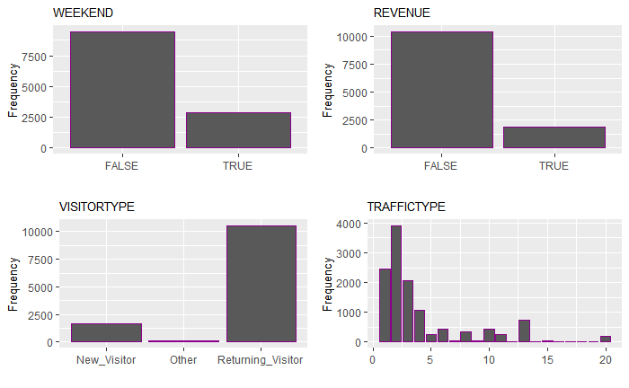

```r
# Plotting histograms
fac_cols_2 = c('weekend','revenue','visitortype','traffictype')

columns_2 = colnames(select(df1, all_of(fac_cols_2)))

p_2 = list()
options(repr.plot.width = 10, repr.plot.height = 6)
for (i in 1:4){
  p_2[[i]] = ggplot(df, aes_string(columns_2[i])) + geom_bar(color = 'darkmagenta') + labs(y = 'Frequency', x = '', title = toupper(columns_2[i])) +
  theme(plot.title = element_text(size = 10),
       axis.title.y = element_text(size = 10))
}

do.call(grid.arrange, p_2)
```

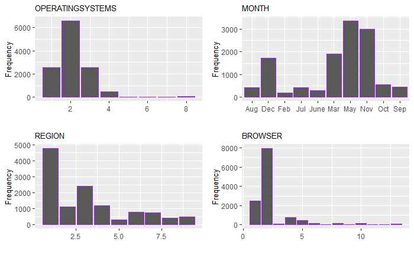

```r
# Plotting histograms
fac_cols = c('operatingsystems','month','region','browser')

columns = colnames(select(df1, all_of(fac_cols)))

p = list()
options(repr.plot.width = 10, repr.plot.height = 7)
for (i in 1:4){
  p[[i]] = ggplot(df, aes_string(columns[i])) + geom_bar(color = 'purple') + labs(y = 'Frequency', x = '', title = toupper(columns[i])) +
  theme(plot.title = element_text(size = 10),
       axis.title.y = element_text(size = 10))
}

do.call(grid.arrange, p)
```

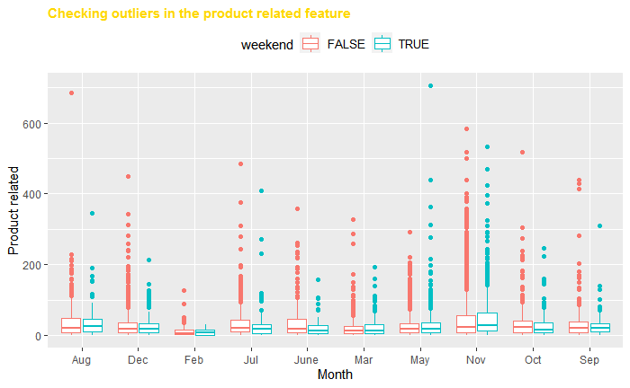

```r
# Plotting boxplots
options(repr.plot.width = 11, repr.plot.height = 5)
ggplot(df1, aes(month, productrelated, col = weekend)) +
  geom_boxplot() +
  labs(x = 'Month', y = 'Product related', title = 'Checking outliers in the product related feature') +
  theme(legend.position = 'top', legend.text = element_text(size = 10),
       plot.title = element_text(size = 11, color = 'gold', face = 'bold'))
```

The visualization shows that during weekdays the outliers tend to be high

### Bivariate

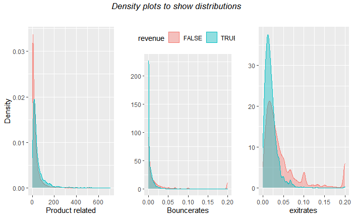

```r
# Plotting density plots to check for distributions
options(repr.plot.width = 11, repr.plot.height = 5)
p1 = ggplot(df1, aes(productrelated, col = revenue)) +
  geom_density(aes(fill = revenue), alpha = 0.4) +
  labs(x = 'Product related', y = 'Density', title = '') +
  theme(legend.position = 'none',
       plot.title = element_text(size = 12))

p2 = ggplot(df1, aes(bouncerates, col = revenue)) +
  geom_density(aes(fill = revenue), alpha = 0.4) +
  labs(x = 'Bouncerates', y = '', title = '') +
  theme(legend.position = 'top')

p3 = ggplot(df1, aes(exitrates, col = revenue)) +
  geom_density(aes(fill = revenue), alpha = 0.4) +
  labs(x = 'exitrates', y = '', title = '') +
  theme(legend.position = 'none',
       plot.title = element_text(size = 12))

grid.arrange(p1, p2, p3, ncol = 3, top = textGrob("Density plots to show distributions",gp=gpar(fontsize=13,font=3, color = 'darkmagenta')))
```

###Multivariate

```r
### Getting the correlation between the numeric variables

corr_df <- cor(num)
corr_df
```

```
                        administrative administrative_duration informational
administrative             1.000000000             0.600409653    0.37528761
administrative_duration    0.600409653             1.000000000    0.30143630
informational              0.375287611             0.301436296    1.00000000
informational_duration     0.254786021             0.237189860    0.61867795
productrelated             0.428191515             0.286783914    0.37260472
productrelated_duration    0.371027224             0.353513793    0.38608372
bouncerates               -0.213666635            -0.137333397   -0.10950530
exitrates                 -0.311274132            -0.202024452   -0.15956681
pagevalues                 0.096920968             0.066168365    0.04739015
specialday                -0.097072098            -0.074736885   -0.04937677
operatingsystems          -0.006697922            -0.007610715   -0.00962587
browser                   -0.025763658            -0.015833675   -0.03876681
region                    -0.007262053            -0.006723711   -0.03047732
traffictype               -0.034784126            -0.015075015   -0.03518669
                        informational_duration productrelated productrelated_duration
administrative                     0.254786021    0.428191515             0.371027224
administrative_duration            0.237189860    0.286783914             0.353513793
informational                      0.618677947    0.372604721             0.386083717
informational_duration             1.000000000    0.279061948             0.346580691
productrelated                     0.279061948    1.000000000             0.860308186
productrelated_duration            0.346580691    0.860308186             1.000000000
bouncerates                       -0.070159472   -0.193515772            -0.174375499
exitrates                         -0.102932678   -0.286163211            -0.245334012
pagevalues                         0.030064160    0.054115494             0.050840624
specialday                        -0.031293040   -0.025930622            -0.038210652
operatingsystems                  -0.009749983    0.004090351             0.002775788
browser                           -0.019609349   -0.013706213            -0.007838332
region                            -0.027920098   -0.040106501            -0.034862498
traffictype                       -0.025163571   -0.044344333            -0.037506944
                         bouncerates    exitrates  pagevalues   specialday operatingsystems
administrative          -0.213666635 -0.311274132  0.09692097 -0.097072098     -0.006697922
administrative_duration -0.137333397 -0.202024452  0.06616837 -0.074736885     -0.007610715
informational           -0.109505298 -0.159566815  0.04739015 -0.049376774     -0.009625870
informational_duration  -0.070159472 -0.102932678  0.03006416 -0.031293040     -0.009749983
productrelated          -0.193515772 -0.286163211  0.05411549 -0.025930622      0.004090351
productrelated_duration -0.174375499 -0.245334012  0.05084062 -0.038210652      0.002775788
bouncerates              1.000000000  0.903358192 -0.11599198  0.087839995      0.026839839
exitrates                0.903358192  1.000000000 -0.17357154  0.116783762      0.016482012
pagevalues              -0.115991977 -0.173571542  1.00000000 -0.064532709      0.018583782
specialday               0.087839995  0.116783762 -0.06453271  1.000000000      0.012757766
operatingsystems         0.026839839  0.016482012  0.01858378  0.012757766      1.000000000
browser                 -0.016018380 -0.003565541  0.04584506  0.003465984      0.212244823
region                   0.001432015 -0.001837556  0.01059087 -0.016452464      0.071953240
traffictype              0.089199039  0.087386232  0.01223694  0.052827944      0.182874100
                             browser       region traffictype
administrative          -0.025763658 -0.007262053 -0.03478413
administrative_duration -0.015833675 -0.006723711 -0.01507502
informational           -0.038766808 -0.030477323 -0.03518669
informational_duration  -0.019609349 -0.027920098 -0.02516357
productrelated          -0.013706213 -0.040106501 -0.04434433
productrelated_duration -0.007838332 -0.034862498 -0.03750694
bouncerates             -0.016018380  0.001432015  0.08919904
exitrates               -0.003565541 -0.001837556  0.08738623
pagevalues               0.045845065  0.010590868  0.01223694
specialday               0.003465984 -0.016452464  0.05282794
operatingsystems         0.212244823  0.071953240  0.18287410
browser                  1.000000000  0.091889464  0.10288624
region                   0.091889464  1.000000000  0.04252523
traffictype              0.102886237  0.042525234  1.00000000
```

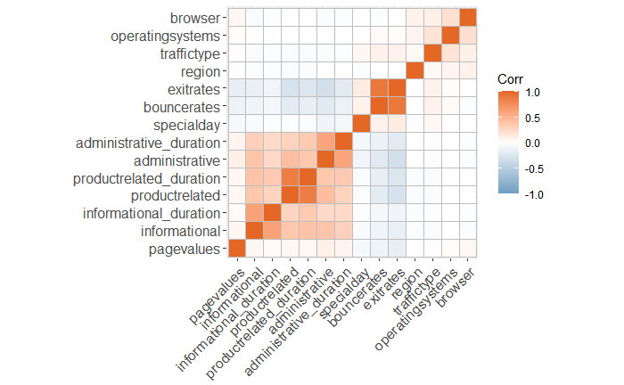

```r
# Plotting a correlogram to check for correlations
options(repr.plot.width = 6, repr.plot.height = 5)

corr = round(cor(select_if(df1, is.numeric)), 2)
ggcorrplot(corr, hc.order = T, ggtheme = ggplot2::theme_gray,
   colors = c("#6D9EC1", "white", "#E46726"), lab = F)
```

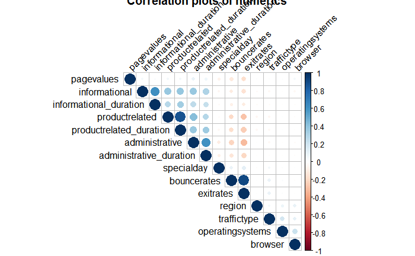

```r
### Showing correlation using correlation plot

corrplot(corr_df, type = "upper", order = "hclust",
         tl.col = "black", tl.srt = 45,main="Correlation plots of numerics")
```

### Scatter plots

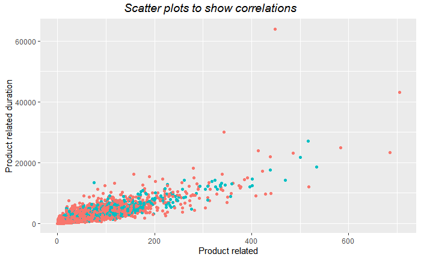

```r
# Plotting scatter plots to check for correlations
options(repr.plot.width = 11, repr.plot.height = 5)

Product = ggplot(df1, aes(productrelated, productrelated_duration, col = revenue)) +
    geom_point() + theme(legend.position = 'none') +
    labs(x='Product related', y ='Product related duration')
grid.arrange(Product,
             top = textGrob("Scatter plots to show correlations",gp=gpar(fontsize=14,font=3, color = 'darkmagenta')))
```

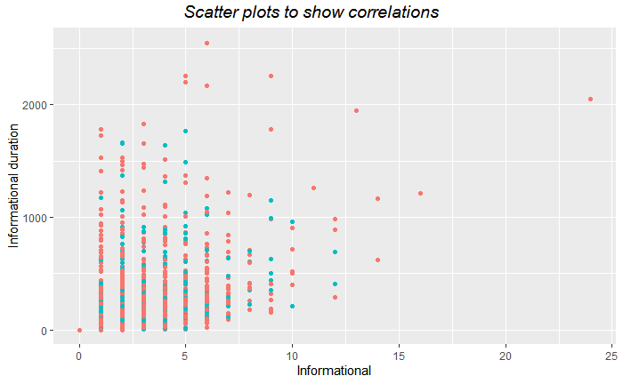

```r
Informational = ggplot(df1, aes(informational, informational_duration, col = revenue)) +
    geom_point() + theme(legend.position = 'none') +
    labs(x = 'Informational', y = 'Informational duration')
grid.arrange(Informational,
             top = textGrob("Scatter plots to show correlations",gp=gpar(fontsize=14,font=3, color = 'darkmagenta')))
```

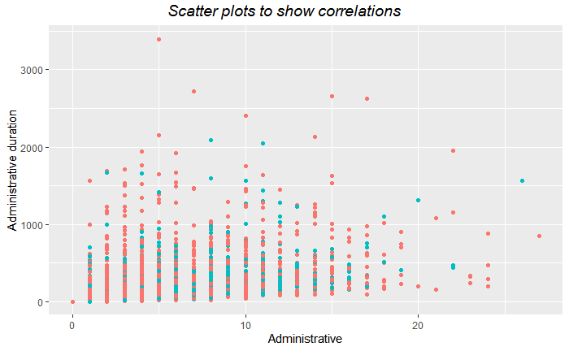

```r
duration = ggplot(df1, aes(administrative, administrative_duration, col = revenue)) +
    geom_point() + theme(legend.position = 'none') +
    labs(x = 'Administrative', y = 'Administrative duration')
grid.arrange(duration,
             top = textGrob("Scatter plots to show correlations",gp=gpar(fontsize=14,font=3, color = 'darkmagenta')))
```

```r
# Creating a copy of the cleaned dataframe
final_df = data.table::copy(df1)
```

# Implement the Solution

### Hierachical clustering

```r
### Encoding categorical variables
month = data.frame(model.matrix(~0+df1$month))
operatingsystems = data.frame(model.matrix(~0+df1$operatingsystems))
browser = data.frame(model.matrix(~0+df1$browser))
region = data.frame(model.matrix(~0+df1$region))
traffictype = data.frame(model.matrix(~0+df1$traffictype))
visitortype = data.frame(model.matrix(~0+df1$visitortype))
weekend = data.frame(model.matrix(~0+df1$weekend))
revenue = data.frame(model.matrix(~0+df1$revenue))
```

```r
# Dropping columns which have already encoded
drop_cols = c('month','operatingsystems','browser','region','traffictype','visitortype','weekend', 'revenue')
df1 = select(data.frame(cbind(df1,month,operatingsystems,browser, region,traffictype, visitortype,weekend, revenue)), -drop_cols)
```

```
Note: Using an external vector in selections is ambiguous.
i Use `all_of(drop_cols)` instead of `drop_cols` to silence this message.
i See <https://tidyselect.r-lib.org/reference/faq-external-vector.html>.
```

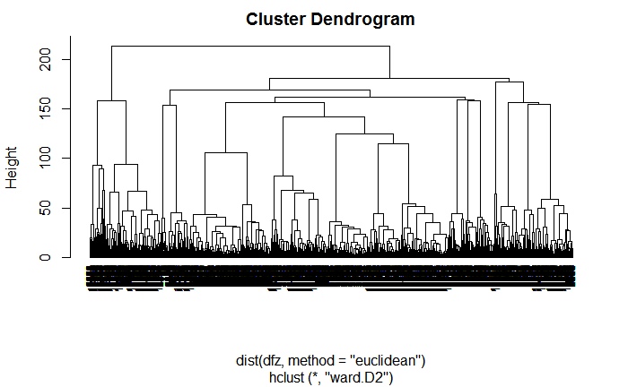

```r
### Scale the data then apply clustering
dfz <- scale(df1)

### We now use the R function hclust() for hierarchical clustering
res_hierachical = hclust(dist(dfz, method = 'euclidean'), method = 'ward.D2')
# ---
#
plot(res_hierachical, cex = 0.6, hang = -1)
```

```r
### Normalising the data
df2 = as.data.frame(apply(df1, 2,  function(x) (x - min(x))/max(x) - min(x)))
```

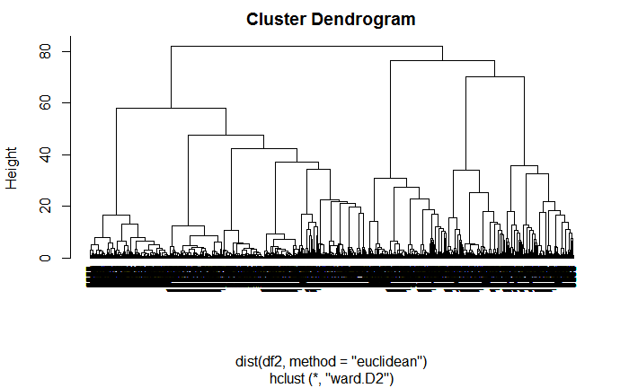

```r
#### The euclidean distance and the ward2 method has been used to perform hierachical clustering
hierachical_res = hclust(dist(df2, method = 'euclidean'), method = 'ward.D2')

#### Visualizing the hierachical dendogram
options(repr.plot.width = 11, repr.plot.height = 6)
plot(hierachical_res, cex = 0.6, hang = -1)
```